# Optimal Treatment Analysis

## Outcome Variable

**Outcome Variable:** whz

## Predictor Variables

**Intervention Variable:** nhh

**Adjustment Set:**

- arm
- W_mage
- meducyrs
- feducyrs
- hhwealth_quart
- W_mhtcm
- W_mwtkg
- W_mbmi
- W_nrooms
- cleanck
- impfloor
- impsan
- safeh20
- delta_W_mage
- delta_meducyrs
- delta_feducyrs
- delta_hhwealth_quart
- delta_W_mhtcm
- delta_W_mwtkg
- delta_W_mbmi
- delta_W_nrooms
- delta_cleanck
- delta_impfloor
- delta_impsan
- delta_safeh20

## Stratifying Variables

The analysis was stratified on these variable(s):

- agecat
- studyid
- country

## Data Summary

| agecat | studyid | country | nhh | n_cell | n |
| --- | --- | --- | --- | --- | --- |
| Birth | ki1000108-IRC | INDIA | 3 or less | 52 | 343 |
| Birth | ki1000108-IRC | INDIA | 4-5 | 131 | 343 |
| Birth | ki1000108-IRC | INDIA | 6-7 | 84 | 343 |
| Birth | ki1000108-IRC | INDIA | 8+ | 76 | 343 |
| Birth | ki1017093-NIH-Birth | BANGLADESH | 3 or less | 7 | 28 |
| Birth | ki1017093-NIH-Birth | BANGLADESH | 4-5 | 11 | 28 |
| Birth | ki1017093-NIH-Birth | BANGLADESH | 6-7 | 7 | 28 |
| Birth | ki1017093-NIH-Birth | BANGLADESH | 8+ | 3 | 28 |
| Birth | ki1017093c-NIH-Crypto | BANGLADESH | 3 or less | 8 | 23 |
| Birth | ki1017093c-NIH-Crypto | BANGLADESH | 4-5 | 7 | 23 |
| Birth | ki1017093c-NIH-Crypto | BANGLADESH | 6-7 | 5 | 23 |
| Birth | ki1017093c-NIH-Crypto | BANGLADESH | 8+ | 3 | 23 |
| 6 months | ki1000108-IRC | INDIA | 3 or less | 57 | 408 |
| 6 months | ki1000108-IRC | INDIA | 4-5 | 157 | 408 |
| 6 months | ki1000108-IRC | INDIA | 6-7 | 107 | 408 |
| 6 months | ki1000108-IRC | INDIA | 8+ | 87 | 408 |
| 6 months | ki1000304b-SAS-FoodSuppl | INDIA | 3 or less | 8 | 97 |
| 6 months | ki1000304b-SAS-FoodSuppl | INDIA | 4-5 | 37 | 97 |
| 6 months | ki1000304b-SAS-FoodSuppl | INDIA | 6-7 | 34 | 97 |
| 6 months | ki1000304b-SAS-FoodSuppl | INDIA | 8+ | 18 | 97 |
| 6 months | ki1017093-NIH-Birth | BANGLADESH | 3 or less | 95 | 536 |
| 6 months | ki1017093-NIH-Birth | BANGLADESH | 4-5 | 227 | 536 |
| 6 months | ki1017093-NIH-Birth | BANGLADESH | 6-7 | 127 | 536 |
| 6 months | ki1017093-NIH-Birth | BANGLADESH | 8+ | 87 | 536 |
| 6 months | ki1017093b-PROVIDE | BANGLADESH | 3 or less | 102 | 582 |
| 6 months | ki1017093b-PROVIDE | BANGLADESH | 4-5 | 277 | 582 |
| 6 months | ki1017093b-PROVIDE | BANGLADESH | 6-7 | 126 | 582 |
| 6 months | ki1017093b-PROVIDE | BANGLADESH | 8+ | 77 | 582 |
| 6 months | ki1017093c-NIH-Crypto | BANGLADESH | 3 or less | 104 | 715 |
| 6 months | ki1017093c-NIH-Crypto | BANGLADESH | 4-5 | 326 | 715 |
| 6 months | ki1017093c-NIH-Crypto | BANGLADESH | 6-7 | 170 | 715 |
| 6 months | ki1017093c-NIH-Crypto | BANGLADESH | 8+ | 115 | 715 |
| 6 months | ki1148112-LCNI-5 | MALAWI | 3 or less | 224 | 816 |
| 6 months | ki1148112-LCNI-5 | MALAWI | 4-5 | 340 | 816 |
| 6 months | ki1148112-LCNI-5 | MALAWI | 6-7 | 182 | 816 |
| 6 months | ki1148112-LCNI-5 | MALAWI | 8+ | 70 | 816 |
| 24 months | ki1000108-IRC | INDIA | 3 or less | 58 | 409 |
| 24 months | ki1000108-IRC | INDIA | 4-5 | 158 | 409 |
| 24 months | ki1000108-IRC | INDIA | 6-7 | 107 | 409 |
| 24 months | ki1000108-IRC | INDIA | 8+ | 86 | 409 |
| 24 months | ki1017093-NIH-Birth | BANGLADESH | 3 or less | 74 | 428 |
| 24 months | ki1017093-NIH-Birth | BANGLADESH | 4-5 | 184 | 428 |
| 24 months | ki1017093-NIH-Birth | BANGLADESH | 6-7 | 100 | 428 |
| 24 months | ki1017093-NIH-Birth | BANGLADESH | 8+ | 70 | 428 |
| 24 months | ki1017093b-PROVIDE | BANGLADESH | 3 or less | 105 | 578 |
| 24 months | ki1017093b-PROVIDE | BANGLADESH | 4-5 | 273 | 578 |
| 24 months | ki1017093b-PROVIDE | BANGLADESH | 6-7 | 117 | 578 |
| 24 months | ki1017093b-PROVIDE | BANGLADESH | 8+ | 83 | 578 |
| 24 months | ki1017093c-NIH-Crypto | BANGLADESH | 3 or less | 69 | 514 |
| 24 months | ki1017093c-NIH-Crypto | BANGLADESH | 4-5 | 232 | 514 |
| 24 months | ki1017093c-NIH-Crypto | BANGLADESH | 6-7 | 130 | 514 |
| 24 months | ki1017093c-NIH-Crypto | BANGLADESH | 8+ | 83 | 514 |
| 24 months | ki1148112-LCNI-5 | MALAWI | 3 or less | 157 | 558 |
| 24 months | ki1148112-LCNI-5 | MALAWI | 4-5 | 230 | 558 |
| 24 months | ki1148112-LCNI-5 | MALAWI | 6-7 | 123 | 558 |
| 24 months | ki1148112-LCNI-5 | MALAWI | 8+ | 48 | 558 |

The following strata were considered:

- agecat: 24 months, studyid: ki1000108-IRC, country: INDIA
- agecat: 24 months, studyid: ki1017093-NIH-Birth, country: BANGLADESH
- agecat: 24 months, studyid: ki1017093b-PROVIDE, country: BANGLADESH
- agecat: 24 months, studyid: ki1017093c-NIH-Crypto, country: BANGLADESH
- agecat: 24 months, studyid: ki1148112-LCNI-5, country: MALAWI
- agecat: 6 months, studyid: ki1000108-IRC, country: INDIA
- agecat: 6 months, studyid: ki1000304b-SAS-FoodSuppl, country: INDIA
- agecat: 6 months, studyid: ki1017093-NIH-Birth, country: BANGLADESH
- agecat: 6 months, studyid: ki1017093b-PROVIDE, country: BANGLADESH
- agecat: 6 months, studyid: ki1017093c-NIH-Crypto, country: BANGLADESH
- agecat: 6 months, studyid: ki1148112-LCNI-5, country: MALAWI
- agecat: Birth, studyid: ki1000108-IRC, country: INDIA
- agecat: Birth, studyid: ki1017093-NIH-Birth, country: BANGLADESH
- agecat: Birth, studyid: ki1017093c-NIH-Crypto, country: BANGLADESH

### Dropped Strata

Some strata were dropped due to rare outcomes:

- agecat: Birth, studyid: ki1017093-NIH-Birth, country: BANGLADESH
- agecat: Birth, studyid: ki1017093c-NIH-Crypto, country: BANGLADESH

## Methods Detail

We’re interested in the causal parameters $E[Y_a]$ for all values of $a \in \mathcal{A}$. These parameters represent the mean outcome if, possibly contrary to fact, we intervened to set all units to have $A=a$. Under the randomization and positivity assumptions, these are identified by the statistical parameters $\psi_a=E_W[E_{Y|A,W}(Y|A=a,W)]$. In addition, we’re interested in the mean of $Y$, $E[Y]$ under no intervention (the observed mean). We will estimate these parameters by using SuperLearner to fit the relevant likelihood factors – $E_{Y|A,W}(Y|A=a,W)$ and $p(A=a|W)$, and then updating our likelihood fit using a joint TMLE.

For unadjusted analyses ($W=\{\}$), initial likelihoods were estimated using Lrnr_glm to estimate the simple $E(Y|A)$ and Lrnr_mean to estimate $p(A)$. For adjusted analyses, a small library containing Lrnr_glmnet, Lrnr_xgboost, and Lrnr_mean was used.

# Results Detail

## Results Plots

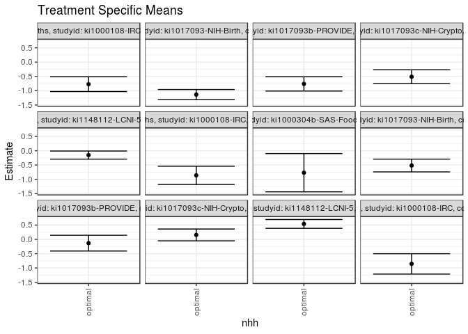

## Results Table

### Parameter: TSM

| agecat | studyid | country | intervention_level | baseline_level | estimate | ci_lower | ci_upper |
| --- | --- | --- | --- | --- | --- | --- | --- |
| Birth | ki1000108-IRC | INDIA | optimal | observed | -0.8579841 | -1.2140529 | -0.5019154 |
| 6 months | ki1000108-IRC | INDIA | optimal | observed | -0.8610876 | -1.1796650 | -0.5425101 |
| 6 months | ki1000304b-SAS-FoodSuppl | INDIA | optimal | observed | -0.7678081 | -1.4373439 | -0.0982722 |
| 6 months | ki1017093-NIH-Birth | BANGLADESH | optimal | observed | -0.5167048 | -0.7398097 | -0.2935998 |
| 6 months | ki1017093b-PROVIDE | BANGLADESH | optimal | observed | -0.1314317 | -0.4067301 | 0.1438667 |
| 6 months | ki1017093c-NIH-Crypto | BANGLADESH | optimal | observed | 0.1553418 | -0.0512613 | 0.3619449 |
| 6 months | ki1148112-LCNI-5 | MALAWI | optimal | observed | 0.5404579 | 0.3862687 | 0.6946471 |
| 24 months | ki1000108-IRC | INDIA | optimal | observed | -0.7715174 | -1.0294140 | -0.5136208 |
| 24 months | ki1017093-NIH-Birth | BANGLADESH | optimal | observed | -1.1366585 | -1.3154596 | -0.9578574 |
| 24 months | ki1017093b-PROVIDE | BANGLADESH | optimal | observed | -0.7629283 | -1.0122140 | -0.5136427 |
| 24 months | ki1017093c-NIH-Crypto | BANGLADESH | optimal | observed | -0.5127671 | -0.7563607 | -0.2691735 |
| 24 months | ki1148112-LCNI-5 | MALAWI | optimal | observed | -0.1524253 | -0.2943881 | -0.0104626 |

### Parameter: E(Y)

| agecat | studyid | country | intervention_level | baseline_level | estimate | ci_lower | ci_upper |
| --- | --- | --- | --- | --- | --- | --- | --- |
| Birth | ki1000108-IRC | INDIA | observed | observed | -1.0105831 | -1.1973019 | -0.8238643 |
| 6 months | ki1000108-IRC | INDIA | observed | observed | -0.5989297 | -0.7344491 | -0.4634104 |
| 6 months | ki1000304b-SAS-FoodSuppl | INDIA | observed | observed | -1.1301031 | -1.3613760 | -0.8988302 |
| 6 months | ki1017093-NIH-Birth | BANGLADESH | observed | observed | -0.4389101 | -0.5279432 | -0.3498771 |
| 6 months | ki1017093b-PROVIDE | BANGLADESH | observed | observed | -0.2083706 | -0.2927992 | -0.1239419 |
| 6 months | ki1017093c-NIH-Crypto | BANGLADESH | observed | observed | 0.0297622 | -0.0491685 | 0.1086930 |
| 6 months | ki1148112-LCNI-5 | MALAWI | observed | observed | 0.4418137 | 0.3703100 | 0.5133174 |
| 24 months | ki1000108-IRC | INDIA | observed | observed | -0.7458150 | -0.8368180 | -0.6548120 |
| 24 months | ki1017093-NIH-Birth | BANGLADESH | observed | observed | -0.9115790 | -1.0095022 | -0.8136559 |
| 24 months | ki1017093b-PROVIDE | BANGLADESH | observed | observed | -0.8879412 | -0.9708680 | -0.8050144 |
| 24 months | ki1017093c-NIH-Crypto | BANGLADESH | observed | observed | -0.6103502 | -0.7050157 | -0.5156847 |
| 24 months | ki1148112-LCNI-5 | MALAWI | observed | observed | -0.0478674 | -0.1301904 | 0.0344557 |

### Parameter: PAR

| agecat | studyid | country | intervention_level | baseline_level | estimate | ci_lower | ci_upper |
| --- | --- | --- | --- | --- | --- | --- | --- |
| Birth | ki1000108-IRC | INDIA | optimal | observed | -0.1525990 | -0.4699478 | 0.1647499 |
| 6 months | ki1000108-IRC | INDIA | optimal | observed | 0.2621578 | -0.0268291 | 0.5511448 |
| 6 months | ki1000304b-SAS-FoodSuppl | INDIA | optimal | observed | -0.3622950 | -1.0259156 | 0.3013255 |
| 6 months | ki1017093-NIH-Birth | BANGLADESH | optimal | observed | 0.0777946 | -0.1232889 | 0.2788781 |
| 6 months | ki1017093b-PROVIDE | BANGLADESH | optimal | observed | -0.0769389 | -0.3330209 | 0.1791431 |
| 6 months | ki1017093c-NIH-Crypto | BANGLADESH | optimal | observed | -0.1255795 | -0.3269702 | 0.0758111 |
| 6 months | ki1148112-LCNI-5 | MALAWI | optimal | observed | -0.0986442 | -0.2320098 | 0.0347215 |
| 24 months | ki1000108-IRC | INDIA | optimal | observed | 0.0257024 | -0.2110864 | 0.2624911 |
| 24 months | ki1017093-NIH-Birth | BANGLADESH | optimal | observed | 0.2250794 | 0.0626785 | 0.3874803 |
| 24 months | ki1017093b-PROVIDE | BANGLADESH | optimal | observed | -0.1250128 | -0.3560347 | 0.1060090 |
| 24 months | ki1017093c-NIH-Crypto | BANGLADESH | optimal | observed | -0.0975831 | -0.3141817 | 0.1190156 |
| 24 months | ki1148112-LCNI-5 | MALAWI | optimal | observed | 0.1045579 | -0.0177315 | 0.2268474 |